# Atividade prática 1 - Modelagem Estatística

Maicon Henrique de Oliveira Gomes

## 1. Introdução

O objetivo desta análise é investigar quais fatores estão associados ao desempenho dos estudantes em uma avaliação. Especificamente, busca-se verificar se existe associação entre as horas dedicadas aos estudos e a nota final obtida pelos estudantes.

Além disso, será analisado se essa associação permanece após considerar outras variáveis relacionadas ao desempenho, como a frequência às aulas e o tipo de grupo de estudo, classificado em “Tradicional” ou “Projeto”.

A análise seguirá um fluxo composto por exploração dos dados, inferência estatística, regressão linear e diagnóstico do modelo. Dessa forma, pretende-se responder à seguinte questão:

Existe associação entre as horas de estudo e a nota final, e essa relação permanece após considerar a frequência e o grupo de estudo?

## 2. Dados e preparação

Para esta análise, foi utilizada uma base de dados simulada contendo informações de 80 estudantes.

As variáveis consideradas são:

- `aluno`: identificador do estudante;
- `grupo`: tipo de grupo de estudo;
- `horas_estudo`: quantidade de horas dedicadas aos estudos;
- `frequencia`: percentual de frequência às aulas;
- `nota_final`: nota obtida pelo estudante na avaliação.

A base foi simulada de forma controlada, utilizando uma semente fixa para permitir a reprodução dos resultados.

```r
# Problema: Quais fatores estão associados ao desempenho dos estudantes em uma avaliação

# 1. Base de dados simulada

# Carregua o pacote dplyr
library(dplyr)

set.seed(123)
n <- 80

dados <- tibble::tibble(
    aluno = 1:n,
    grupo = sample(c("Tradicional", "Projeto"), n, TRUE),
    horas_estudo = round(rnorm(n, mean = 6, sd = 2), 1),
    frequencia = round(runif(n, 70, 100), 1),
    nota_final = 45 + 4.2 * horas_estudo + 0.25 * frequencia +
        ifelse(grupo == "Projeto", 4, 0) + rnorm(n, 0, 7)
)

dados <- dados |>
 mutate(
    horas_estudo = pmax(horas_estudo, 0),
    nota_final = pmin(pmax(nota_final, 0), 100)
 )
```

A utilização de `set.seed(123)` garante que a base simulada possa ser reproduzida a partir do mesmo código.

O tratamento realizado posteriormente limita as horas de estudo a valores não negativos e mantém as notas dentro do intervalo de 0 a 100.

## 3. Análise exploratória

Antes da aplicação dos modelos estatísticos, foi realizada uma análise exploratória para compreender as características gerais dos dados e identificar possíveis associações iniciais entre as variáveis.

### 3.1 Medidas-resumo

Inicialmente, foram calculadas a média e o desvio-padrão da nota final, a média das horas de estudo e a correlação entre horas de estudo e nota final.

```r
# 2. Análise exploratória

# Carregua o pacote tidyverse
library(tidyverse)

# Distribuição e o relacionamento entre variáveis
dados |>
    summarise(
        media_nota = mean(nota_final),
        dp_nota = sd(nota_final),
        media_estudo = mean(horas_estudo),
        cor_estudo_nota = cor(horas_estudo, nota_final)
    )
```

```
## # A tibble: 1 × 4
##   media_nota dp_nota media_estudo cor_estudo_nota
##        <dbl>   <dbl>        <dbl>           <dbl>
## 1       91.3    8.23            6           0.724
```

A média da nota final foi de 91.3 pontos, com desvio-padrão de 8.23 pontos.

A média de horas de estudo foi de 6 horas.

A correlação de Pearson entre horas de estudo e nota final foi de 0.724.

Esse resultado indica a direção e a intensidade da associação linear entre as duas variáveis. Uma correlação positiva indica que, na amostra, valores maiores de horas de estudo tendem a estar associados a valores maiores de nota final.

Entretanto, a correlação não deve ser interpretada como evidência de causalidade.

### 3.2 Distribuição dos estudantes por grupo

```r
dados |>
    count(grupo)
```

```
## # A tibble: 2 × 2
##   grupo           n
##   <chr>       <int>
## 1 Projeto        32
## 2 Tradicional    48
```

A distribuição dos estudantes entre os grupos permite verificar se existe algum desequilíbrio importante no tamanho das amostras antes da comparação das médias.

Essa informação será considerada posteriormente no teste de hipótese que compara as notas dos grupos Tradicional e Projeto.

### 3.3 Relação entre horas de estudo e nota final

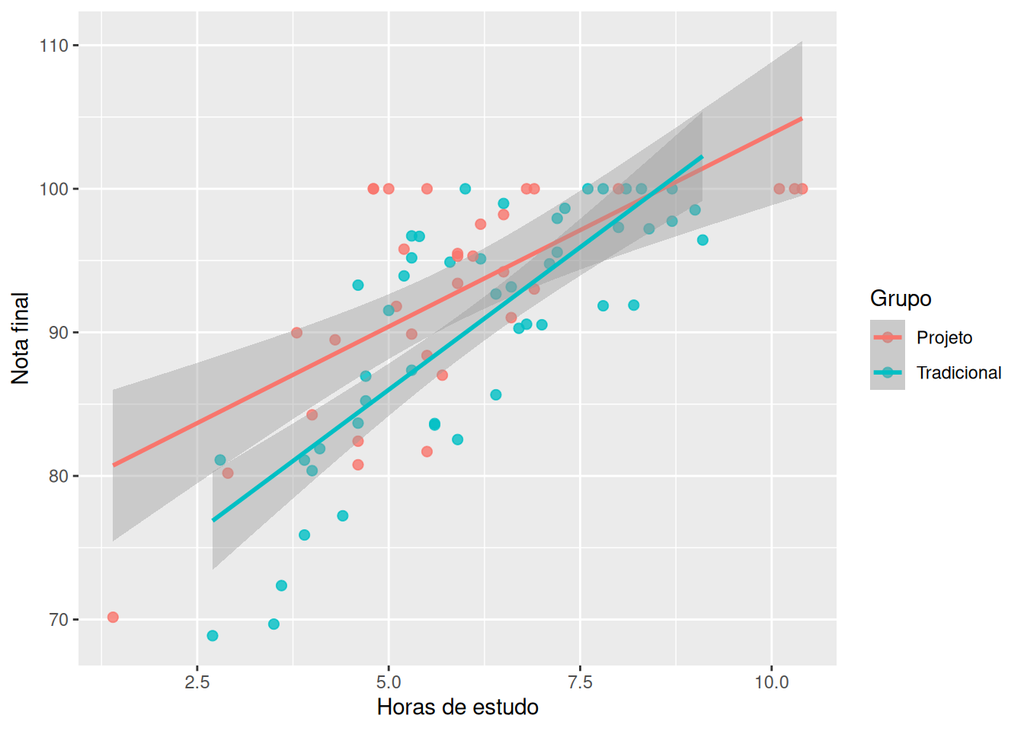

```r
ggplot(dados, aes(x = horas_estudo, y = nota_final, color = grupo)) +
    geom_point(size = 2, alpha = 0.8) +
    geom_smooth(method = "lm", se = TRUE) +
    labs(x = "Horas de estudo", y = "Nota final", color = "Grupo")
```

O gráfico permite observar visualmente a relação entre horas de estudo e nota final, além de possibilitar uma comparação inicial entre os grupos.

A reta de regressão representa a tendência linear estimada para os dados, enquanto a região ao redor da reta representa o intervalo de confiança da estimativa.

A presença de uma tendência positiva é compatível com uma associação entre maior quantidade de horas de estudo e maiores notas. Entretanto, essa análise é exploratória e deve ser complementada pelos modelos estatísticos apresentados posteriormente.

## 4. Inferência e modelo

### 4.1 Intervalo de confiança

Foi calculado um intervalo de confiança de 95% para a média populacional da nota final.

```r
# 3. Intervalo de confiança

# Estimando a média da nota final com incerteza
media <- mean(dados$nota_final)
dp <- sd(dados$nota_final)
n <- nrow(dados)
erro <- qt(0.975, df = n - 1) * dp / sqrt(n)

ic_media <- tibble(
    media = media,
    limite_inferior = media - erro,
    limite_superior = media + erro
)

ic_media
```

```
## # A tibble: 1 × 3
##   media limite_inferior limite_superior
##   <dbl>           <dbl>           <dbl>
## 1  91.3            89.5            93.1
```

A média amostral da nota final foi de 91.3 pontos.

O intervalo de confiança de 95% foi de [89.47; 93.13] pontos.

Esse intervalo representa uma faixa de valores plausíveis para a média populacional da nota final, considerando as suposições do método utilizado.

A amplitude do intervalo é de aproximadamente 3.66 pontos, permitindo avaliar a precisão da estimativa da média.

A interpretação frequentista do intervalo de confiança é que, em repetidas amostragens realizadas sob as mesmas condições, aproximadamente 95% dos intervalos construídos pelo mesmo procedimento conteriam o verdadeiro parâmetro populacional.

### 4.2 Teste de hipótese

Para comparar o desempenho médio entre os grupos Tradicional e Projeto, foi utilizado um teste t para duas amostras.

As hipóteses consideradas foram:

- **H0:** as médias das notas finais são iguais entre os grupos Tradicional e Projeto;
- **H1:** as médias das notas finais são diferentes entre os grupos Tradicional e Projeto.

```r
# 4. Teste de hipótese

# Comparando a média da nota entre dois grupos, H0 = médias iguais e H1 = médias diferentes
teste_grupo <- t.test(nota_final ~ grupo, data = dados)
teste_grupo
```

```
##
##  Welch Two Sample t-test
##
## data:  nota_final by grupo
## t = 1.2463, df = 71.628, p-value = 0.2167
## alternative hypothesis: true difference in means between group Projeto and group Tradicional is not equal to 0
## 95 percent confidence interval:
##  -1.367811  5.929405
## sample estimates:
##     mean in group Projeto mean in group Tradicional
##                  92.66715                  90.38635
```

As médias e os desvios-padrão de cada grupo são apresentados abaixo:

```r
dados |>
    group_by(grupo) |>
    summarise(
        media = mean(nota_final),
        dp = sd(nota_final),
        n = n(),
        .groups = "drop"
        )
```

```
## # A tibble: 2 × 4
##   grupo       media    dp     n
##   <chr>       <dbl> <dbl> <int>
## 1 Projeto      92.7  7.63    32
## 2 Tradicional  90.4  8.57    48
```

O teste t apresentou p-valor de 0.217.

O intervalo de confiança de 95% para a diferença entre as médias foi de [-1.37; 5.93] pontos.

Considerando um nível de significância de 5%, não se rejeita a hipótese nula.

Assim, os dados não fornecem evidências suficientes de uma diferença estatisticamente significativa entre as médias dos grupos.

É importante distinguir significância estatística de importância prática. Mesmo quando uma diferença é estatisticamente significativa, sua magnitude deve ser considerada para avaliar sua relevância no contexto do problema.

### 4.3 Regressão linear simples

Para investigar a associação entre horas de estudo e nota final, foi ajustado um modelo de regressão linear simples.

```r
# 5. Regressão linear simples

# Modelando nota final a partir das horas de estudo
modelo_1 <- lm(nota_final ~ horas_estudo, data = dados)
summary(modelo_1)
```

```
##
## Call:
## lm(formula = nota_final ~ horas_estudo, data = dados)
##
## Residuals:
##      Min       1Q   Median       3Q      Max
## -13.3018  -4.1277  -0.1565   3.9431  12.6939
##
## Coefficients:
##              Estimate Std. Error t value Pr(>|t|)
## (Intercept)   71.3357     2.2461  31.760  < 2e-16 ***
## horas_estudo   3.3272     0.3589   9.271 3.22e-14 ***
## ---
## Signif. codes:  0 '***' 0.001 '**' 0.01 '*' 0.05 '.' 0.1 ' ' 1
##
## Residual standard error: 5.715 on 78 degrees of freedom
## Multiple R-squared:  0.5242, Adjusted R-squared:  0.5181
## F-statistic: 85.95 on 1 and 78 DF,  p-value: 3.221e-14
```

```r
broom::tidy(modelo_1, conf.int = TRUE)
```

```
## # A tibble: 2 × 7
##   term         estimate std.error statistic  p.value conf.low conf.high
##   <chr>           <dbl>     <dbl>     <dbl>    <dbl>    <dbl>     <dbl>
## 1 (Intercept)     71.3      2.25      31.8  2.26e-46    66.9      75.8
## 2 horas_estudo     3.33     0.359      9.27 3.22e-14     2.61      4.04
```

```r
broom::glance(modelo_1)
```

```
## # A tibble: 1 × 12
##   r.squared adj.r.squared sigma statistic  p.value    df logLik   AIC   BIC
##       <dbl>         <dbl> <dbl>     <dbl>    <dbl> <dbl>  <dbl> <dbl> <dbl>
## 1     0.524         0.518  5.72      85.9 3.22e-14     1  -252.  510.  517.
## # ℹ 3 more variables: deviance <dbl>, df.residual <int>, nobs <int>
```

O coeficiente associado às horas de estudo representa a variação média estimada na nota final associada a um aumento de uma hora nas horas de estudo.

Para apresentar esse resultado diretamente a partir do modelo ajustado:

```r
coef_modelo_1 <- broom::tidy(modelo_1, conf.int = TRUE)
ajuste_modelo_1 <- broom::glance(modelo_1)

coef_modelo_1
```

```
## # A tibble: 2 × 7
##   term         estimate std.error statistic  p.value conf.low conf.high
##   <chr>           <dbl>     <dbl>     <dbl>    <dbl>    <dbl>     <dbl>
## 1 (Intercept)     71.3      2.25      31.8  2.26e-46    66.9      75.8
## 2 horas_estudo     3.33     0.359      9.27 3.22e-14     2.61      4.04
```

```r
ajuste_modelo_1
```

```
## # A tibble: 1 × 12
##   r.squared adj.r.squared sigma statistic  p.value    df logLik   AIC   BIC
##       <dbl>         <dbl> <dbl>     <dbl>    <dbl> <dbl>  <dbl> <dbl> <dbl>
## 1     0.524         0.518  5.72      85.9 3.22e-14     1  -252.  510.  517.
## # ℹ 3 more variables: deviance <dbl>, df.residual <int>, nobs <int>
```

O coeficiente estimado para `horas_estudo` foi de 3.327 pontos por hora.

Isso significa que, no modelo simples, um aumento de uma hora nas horas de estudo está associado, em média, a uma variação estimada de 3.327 pontos na nota final.

O intervalo de confiança de 95% para esse coeficiente foi de [2.613; 4.042].

O p-valor associado ao coeficiente foi <0.001.

O coeficiente de determinação foi R² = 0.524, indicando que aproximadamente 52.4%** da variabilidade observada na nota final é explicada pelo modelo que utiliza apenas as horas de estudo como variável explicativa.

É importante destacar que o modelo descreve uma associação entre as variáveis e, por si só, não estabelece uma relação causal.

### Visualização do modelo simples

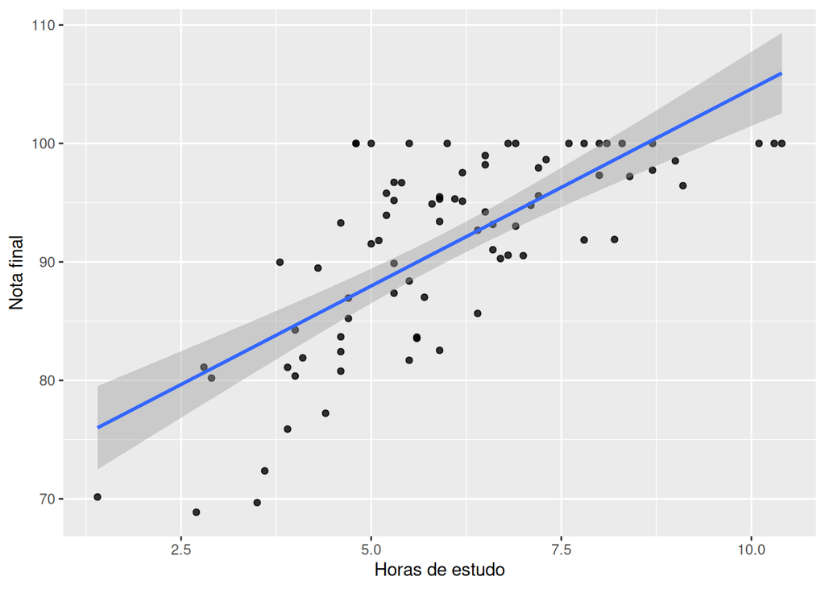

```r
ggplot(dados, aes(horas_estudo, nota_final)) +
    geom_point(alpha = 0.8) +
    geom_smooth(method = "lm", se = TRUE) +
    labs(x = "Horas de estudo", y = "Nota final")
```

O gráfico apresenta os valores observados e a reta de regressão estimada.

A distribuição dos pontos em torno da reta auxilia na avaliação visual da relação linear entre as horas de estudo e a nota final.

### 4.4 Modelo com múltiplas variáveis

Na etapa seguinte, foi ajustado um modelo de regressão linear múltipla incluindo `horas_estudo`, `frequencia` e `grupo`.

```r
# 6. Modelo com mais de uma variável

# Considerando frequência e grupo no mesmo modelo
modelo_2 <- lm(nota_final ~ horas_estudo + frequencia + grupo, data = dados)

summary(modelo_2)
```

```
##
## Call:
## lm(formula = nota_final ~ horas_estudo + frequencia + grupo,
##     data = dados)
##
## Residuals:
##      Min       1Q   Median       3Q      Max
## -10.5570  -3.8676   0.0294   3.4684  11.2953
##
## Coefficients:
##                  Estimate Std. Error t value Pr(>|t|)
## (Intercept)      60.77412    6.11984   9.931 2.25e-15 ***
## horas_estudo      3.39416    0.34067   9.963 1.95e-15 ***
## frequencia        0.14246    0.06727   2.118   0.0375 *
## grupoTradicional -3.13042    1.23824  -2.528   0.0135 *
## ---
## Signif. codes:  0 '***' 0.001 '**' 0.01 '*' 0.05 '.' 0.1 ' ' 1
##
## Residual standard error: 5.411 on 76 degrees of freedom
## Multiple R-squared:  0.5845, Adjusted R-squared:  0.568
## F-statistic: 35.63 on 3 and 76 DF,  p-value: 1.744e-14
```

```r
broom::tidy(modelo_2, conf.int = TRUE)
```

```
## # A tibble: 4 × 7
##   term             estimate std.error statistic  p.value conf.low conf.high
##   <chr>               <dbl>     <dbl>     <dbl>    <dbl>    <dbl>     <dbl>
## 1 (Intercept)        60.8      6.12        9.93 2.25e-15 48.6        73.0
## 2 horas_estudo        3.39     0.341       9.96 1.95e-15  2.72        4.07
## 3 frequencia          0.142    0.0673      2.12 3.75e- 2  0.00847     0.276
## 4 grupoTradicional   -3.13     1.24       -2.53 1.35e- 2 -5.60       -0.664
```

```r
broom::glance(modelo_2)
```

```
## # A tibble: 1 × 12
##   r.squared adj.r.squared sigma statistic  p.value    df logLik   AIC   BIC
##       <dbl>         <dbl> <dbl>     <dbl>    <dbl> <dbl>  <dbl> <dbl> <dbl>
## 1     0.584         0.568  5.41      35.6 1.74e-14     3  -247.  503.  515.
## # ℹ 3 more variables: deviance <dbl>, df.residual <int>, nobs <int>
```

```r
anova(modelo_1, modelo_2)
```

```
## Analysis of Variance Table
##
## Model 1: nota_final ~ horas_estudo
## Model 2: nota_final ~ horas_estudo + frequencia + grupo
##   Res.Df    RSS Df Sum of Sq     F   Pr(>F)
## 1     78 2547.9
## 2     76 2225.5  2    322.46 5.506 0.005847 **
## ---
## Signif. codes:  0 '***' 0.001 '**' 0.01 '*' 0.05 '.' 0.1 ' ' 1
```

O modelo múltiplo permite analisar a associação entre cada variável explicativa e a nota final considerando simultaneamente as demais variáveis incluídas no modelo.

No caso de `horas_estudo`, o coeficiente representa a associação entre horas de estudo e nota final mantendo constantes a frequência e o grupo.

Para apresentar os resultados dos coeficientes e das medidas de ajuste:

```r
coef_modelo_2 <- broom::tidy(modelo_2, conf.int = TRUE)
ajuste_modelo_2 <- broom::glance(modelo_2)

coef_modelo_2
```

```
## # A tibble: 4 × 7
##   term             estimate std.error statistic  p.value conf.low conf.high
##   <chr>               <dbl>     <dbl>     <dbl>    <dbl>    <dbl>     <dbl>
## 1 (Intercept)        60.8      6.12        9.93 2.25e-15 48.6        73.0
## 2 horas_estudo        3.39     0.341       9.96 1.95e-15  2.72        4.07
## 3 frequencia          0.142    0.0673      2.12 3.75e- 2  0.00847     0.276
## 4 grupoTradicional   -3.13     1.24       -2.53 1.35e- 2 -5.60       -0.664
```

```r
ajuste_modelo_2
```

```
## # A tibble: 1 × 12
##   r.squared adj.r.squared sigma statistic  p.value    df logLik   AIC   BIC
##       <dbl>         <dbl> <dbl>     <dbl>    <dbl> <dbl>  <dbl> <dbl> <dbl>
## 1     0.584         0.568  5.41      35.6 1.74e-14     3  -247.  503.  515.
## # ℹ 3 more variables: deviance <dbl>, df.residual <int>, nobs <int>
```

O coeficiente estimado para `horas_estudo` foi de 3.394 pontos por hora.

O p-valor associado foi de <0.001.

Dessa forma, após considerar simultaneamente as demais variáveis incluídas no modelo, os resultados **indicam uma associação estatisticamente significativa entre horas de estudo e nota final**.

O coeficiente de determinação do modelo múltiplo foi R² = 0.584, enquanto o R² ajustado foi 0.568.

Essas medidas permitem avaliar quanto da variabilidade da nota final é explicada pelo conjunto de variáveis incluídas no modelo.

### Comparação entre os modelos

Para comparar o modelo simples e o modelo múltiplo, foi utilizado o teste de comparação de modelos aninhados já presente no código desenvolvido:

```r
anova(modelo_1, modelo_2)
```

```
## Analysis of Variance Table
##
## Model 1: nota_final ~ horas_estudo
## Model 2: nota_final ~ horas_estudo + frequencia + grupo
##   Res.Df    RSS Df Sum of Sq     F   Pr(>F)
## 1     78 2547.9
## 2     76 2225.5  2    322.46 5.506 0.005847 **
## ---
## Signif. codes:  0 '***' 0.001 '**' 0.01 '*' 0.05 '.' 0.1 ' ' 1
```

O teste de comparação dos modelos apresentou p-valor de 0.00585.

Assim, considerando um nível de significância de 5%, há evidências de que o modelo múltiplo apresenta melhoria estatisticamente significativa no ajuste em relação ao modelo simples.

Além do teste estatístico, a comparação deve considerar o R² ajustado, a interpretação dos coeficientes e a finalidade da análise.

Portanto, a inclusão de novas variáveis não deve ser considerada automaticamente uma melhoria apenas porque o R² aumenta.

## 5. Diagnóstico do modelo

A validade da regressão linear depende de algumas suposições relacionadas aos resíduos.

Para avaliá-las, foram utilizados os quatro gráficos diagnósticos do modelo múltiplo.

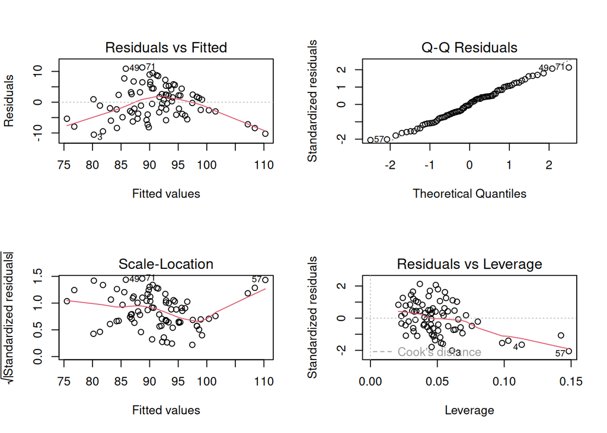

```r
# 7. Diagnóstico do modelo

# Verificação das suposições
par(mfrow = c(2,2))
plot(modelo_2)
```

```r
par(mfrow = c(1,1))
```

### Linearidade

O gráfico Residuals vs Fitted permite verificar se existe algum padrão sistemático nos resíduos.

Um comportamento aproximadamente aleatório dos resíduos ao redor de zero é compatível com a hipótese de linearidade.

### Normalidade dos resíduos

O gráfico Normal Q-Q permite avaliar se os resíduos apresentam comportamento aproximadamente normal.

Quanto mais próximos os pontos estiverem da linha de referência, maior a compatibilidade com essa suposição.

### Homocedasticidade

O gráfico Scale-Location permite verificar se a variabilidade dos resíduos permanece aproximadamente constante ao longo dos valores ajustados.

Uma dispersão aproximadamente uniforme dos pontos é compatível com a hipótese de homocedasticidade.

### Observações influentes

O gráfico Residuals vs Leverage auxilia na identificação de observações que podem exercer influência excessiva sobre o modelo.

A distância de Cook também auxilia nessa avaliação.

A interpretação final desses pressupostos deve ser realizada a partir dos gráficos efetivamente produzidos pelo modelo, evitando conclusões baseadas apenas em valores numéricos.

## 6. Conclusão

A análise teve como objetivo investigar a associação entre as horas de estudo e a nota final dos estudantes, considerando também a frequência às aulas e o grupo de estudo.

A análise exploratória permitiu observar as características gerais da base e identificar inicialmente a relação entre horas de estudo e desempenho. A correlação calculada forneceu uma medida da associação linear entre essas variáveis, enquanto o gráfico permitiu visualizar essa relação e sua dispersão.

O intervalo de confiança de 95% forneceu uma faixa de valores plausíveis para a média populacional da nota final, permitindo representar a incerteza associada à estimativa obtida a partir da amostra.

O teste t possibilitou comparar as médias dos grupos Tradicional e Projeto. A decisão sobre a hipótese nula foi baseada no p-valor obtido, considerando o nível de significância de 5%. A interpretação deve, entretanto, considerar também a magnitude da diferença observada entre os grupos.

Na regressão linear simples, as horas de estudo foram utilizadas como variável explicativa da nota final. O coeficiente estimado representa a associação média entre essas variáveis, enquanto o R² indica a proporção da variabilidade da nota final explicada pelo modelo.

Em seguida, foi ajustado um modelo de regressão linear múltipla incluindo horas de estudo, frequência e grupo. Nesse modelo, o coeficiente de horas de estudo representa sua associação com a nota final após considerar as demais variáveis incluídas.

A comparação entre os modelos, realizada por meio de `anova(modelo_1, modelo_2)`, permite avaliar se a inclusão de frequência e grupo produz uma melhoria estatisticamente significativa no ajuste em relação ao modelo que utiliza somente horas de estudo.

Por fim, o diagnóstico dos resíduos permite avaliar se as principais suposições da regressão linear são razoavelmente atendidas, incluindo linearidade, normalidade dos resíduos, homocedasticidade e presença de observações potencialmente influentes.

Dessa forma, a análise integra exploração, inferência, teste de hipóteses, regressão linear e diagnóstico de modelos para investigar os fatores associados ao desempenho dos estudantes.

É importante ressaltar que os dados utilizados são simulados** e que os resultados representam associações observadas nessa base de dados. Portanto, os resultados não devem ser interpretados automaticamente como evidência de relações causais.